# Package metadata

The job of the `DESCRIPTION` file is to store important metadata about your package. As time goes by and you start sharing your package with others, the metadata file becomes increasingly important because it specifies who can use it (the license) and whom to contact (you!) if there are any problems.

Every package must have a `DESCRIPTION`. In fact, it’s the defining feature of a package (RStudio and devtools consider any directory containing `DESCRIPTION` to be a package). To get you started, `usethis::create_package("mypackage")` automatically adds a bare-bones description file. The minimal description will vary a bit depending on your settings, but should look something like this:

```yaml
Package: mypackage
Title: What The Package Does (one line, title case required)
Version: 0.1
Authors@R: person("First", "Last", email = "first.last@example.com",
                  role = c("aut", "cre"))
Description: What the package does (one paragraph)
Depends: R (>= 3.1.0)
License: What license is it under?
LazyData: true
```

`DESCRIPTION` uses a simple file format called DCF, the Debian control format. You can see most of the structure in the simple example below. Each line consists of a **field** name and a value, separated by a colon. When values span multiple lines, they need to be indented:

```yaml
Description: The description of a package is usually long,
    spanning multiple lines. The second and subsequent lines
    should be indented, usually with four spaces.
```

This chapter will show you how to use the most important `DESCRIPTION` fields.

## Dependencies: What does your package need?

It’s the job of the `DESCRIPTION` to list the packages that your package needs to work. R has a rich set of ways of describing potential dependencies. For example, the following lines indicate that your package needs both ggvis and dplyr to work:

```yaml
Imports:
    dplyr,
    ggvis
```

Whereas, the lines below indicate that while your package can take advantage of ggvis and dplyr, they’re not required to make it work:

```yaml
Suggests:
    dplyr,
    ggvis
```

Both `Imports` and `Suggests` take a comma separated list of package names.

`Imports` and `Suggests` differ in their strength of dependency:

- `Imports`: packages listed here *must* be present for your package to work. In fact, any time your package is installed, those packages will, if not already present, be installed on your computer (`devtools::load_all()` also checks that the packages are installed).

  Adding a package dependency here ensures that it’ll be installed. However, it does *not* mean that it will be attached along with your package (i.e., `library(x)`). The best practice is to explicitly refer to external functions using the syntax `package::function()`. This makes it very easy to identify which functions live outside of your package. This is especially useful when you read your code in the future.

  If you use a lot of functions from other packages this is rather verbose. There’s also a minor performance penalty associated with `::` (on the order of 5µs, so it will only matter if you call the function millions of times). You’ll learn about alternative ways to call functions in other packages in namespace imports.

  When you use import, package will be in your memory, but in suggest package will not be in memory.
- `Suggests`: your package can use these packages, but doesn’t require them. You might use suggested packages for example datasets, to run tests, build vignettes, or maybe there’s only one function that needs the package.

  Packages listed in `Suggests` are not automatically installed along with your package. This means that you need to check if the package is available before using it (use `requireNamespace(x, quietly = TRUE)`). There are two basic scenarios:

  ```r
  # You need the suggested package for this function
  my_fun <- function(a, b) {
    if (!requireNamespace("pkg", quietly = TRUE)) {
      stop("Package \"pkg\" needed for this function to work. Please install it.",
        call. = FALSE)
    }
  }

  # There's a fallback method if the package isn't available
  my_fun <- function(a, b) {
    if (requireNamespace("pkg", quietly = TRUE)) {
      pkg::f()
    } else {
      g()
    }
  }
  ```

When developing packages locally, you never need to use `Suggests`. When releasing your package, using `Suggests` is a courtesy to your users. It frees them from downloading rarely needed packages, and lets them get started with your package as quickly as possible.

### Versioning

If you need a specific version of a package, specify it in parentheses after the package name:

```yaml
Imports:
    ggvis (>= 0.2),
    dplyr (>= 0.3.0.1)
Suggests:
    MASS (>= 7.3.0)
```

You almost always want to specify a minimum version rather than an exact version (`MASS (== 7.3.0)`). Since R can’t have multiple versions of the same package loaded at the same time, specifying an exact dependency dramatically increases the chance of conflicting versions.

Versioning is most important when you release your package. Usually people don’t have exactly the same versions of packages installed that you do. If someone has an older package that doesn’t have a function your package needs, they’ll get an unhelpful error message. However, if you supply the version number, they’ll get a error message that tells them exactly what the problem is: an out of date package.

Think carefully if you declare a minimum version. In some sense, the safest thing to do is to require a version greater than or equal to the package’s current version. For public work, this is most naturally defined as the current CRAN version of a package; private or personal projects may adopt some other convention. But it’s important to appreciate the implications for people who try to install your package: if their local installation doesn’t fulfill all of your requirements around versions, installation will either fail or force upgrades of these dependencies. This is desirable if your minimum version requirements are genuine, i.e. your package would be broken otherwise. But if your stated requirements have a less solid rationale, this may be unnecessarily conservative and inconvenient.

There are three other fields that allow you to express more specialised dependencies:

- `Depends`: Prior to the rollout of namespaces in R 2.14.0, `Depends` was the only way to “depend” on another package. Now, despite the name, you should almost always use `Imports`, not `Depends`. You’ll learn why, and when you should still use `Depends`, in namespaces.

  You can also use `Depends` to require a specific version of R, e.g. `Depends: R (>= 3.4.0)`. Again, think carefully if you do this. This raises the same issues as setting a minimum version for a package you depend on, except the stakes are much higher when it comes to R itself. Users can’t simply consent to the necessary upgrade, so, if other packages depend on yours, your minimum version requirement for R can cause a cascade of package installation failures.
- `LinkingTo`: packages listed here rely on C or C++ code in another package. You’ll learn more about `LinkingTo` in compiled code.
- `Enhances`: packages listed here are “enhanced” by your package. Typically, this means you provide methods for classes defined in another package (a sort of reverse `Suggests`). But it’s hard to define what that means, so I don’t recommend using `Enhances`.

## Title and description: What does your package do?

The title and description fields describe what the package does. They differ only in length:

- `Title` is a one line description of the package, and is often shown in package listing. It should be plain text (no markup), capitalised like a title, and NOT end in a period. Keep it short: listings will often truncate the title to 65 characters.
- `Description` is more detailed than the title. You can use multiple sentences but you are limited to one paragraph. If your description spans multiple lines (and it should!), each line must be no more than 80 characters wide. Indent subsequent lines with 4 spaces.

The `Title` and `Description` for ggplot2 are:

```yaml
Title: An implementation of the Grammar of Graphics
Description: An implementation of the grammar of graphics in R. It combines
    the advantages of both base and lattice graphics: conditioning and shared
    axes are handled automatically, and you can still build up a plot step
    by step from multiple data sources. It also implements a sophisticated
    multidimensional conditioning system and a consistent interface to map
    data to aesthetic attributes. See the ggplot2 website for more information,
    documentation and examples.
```

A good title and description are important, especially if you plan to release your package to CRAN because they appear on the CRAN download page as follows:

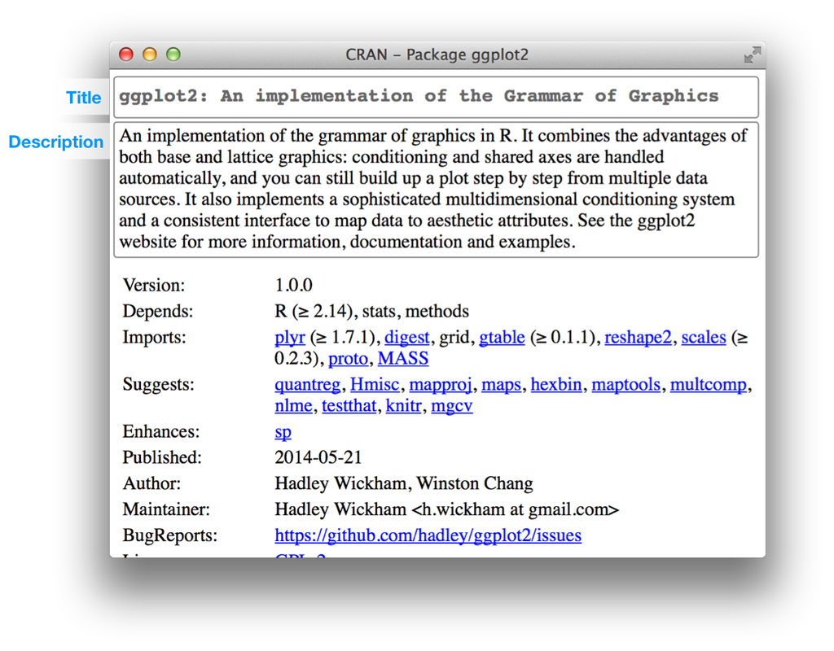

```r
knitr::include_graphics("./cran-package.png")
```

Because `Description` only gives you a small amount of space to describe what your package does, I also recommend including a `README.md` file that goes into much more depth and shows a few examples. You’ll learn about that in README.md.

## Author: who are you?

To identify the package’s author, and whom to contact if something goes wrong, use the `Authors@R` field. This field is unusual because it contains executable R code rather than plain text. Here’s an example:

```yaml
Authors@R: person("Hadley", "Wickham", email = "hadley@rstudio.com",
  role = c("aut", "cre"))
```

```r
person("Hadley", "Wickham", email = "hadley@rstudio.com",
  role = c("aut", "cre"))
```

```
#> [1] "Hadley Wickham <hadley@rstudio.com> [aut, cre]"
```

This command says that both the author (aut) and the maintainer (cre) is Hadley Wickham, and that his email address is `hadley@rstudio.com`. The `person()` function has four main arguments:

- The name, specified by the first two arguments, `given` and `family` (these are normally supplied by position, not name). In English cultures, `given` (first name) comes before `family` (last name). In many cultures, this convention does not hold.
- The `email` address.
- A three letter code specifying the `role`. There are four important roles:
  - `cre`: the creator or maintainer, the person you should bother if you have problems.
  - `aut`: authors, those who have made significant contributions to the package.
  - `ctb`: contributors, those who have made smaller contributions, like patches.
  - `cph`: copyright holder. This is used if the copyright is held by someone other than the author, typically a company (i.e. the author’s employer).

  (The [full list of roles](https://www.loc.gov/marc/relators/relaterm.html) is extremely comprehensive. Should your package have a woodcutter (“wdc”), lyricist (“lyr”) or costume designer (“cst”), rest comfortably that you can correctly describe their role in creating your package.)

If you need to add further clarification, you can also use the `comment` argument and supply the desired information in plain text.

You can list multiple authors with `c()`:

```yaml
Authors@R: c(
    person("Hadley", "Wickham", email = "hadley@rstudio.com", role = "cre"),
    person("Winston", "Chang", email = "winston@rstudio.com", role = "aut"))
```

Every package must have at least one author (aut) and one maintainer (cre) (they might be the same person). The creator must have an email address. These fields are used to generate the basic citation for the package (e.g. `citation("pkgname")`). Only people listed as authors will be included in the auto-generated citation. There are a few extra details if you’re including code that other people have written. Since this typically occurs when you’re wrapping a C library, it’s discussed in compiled code.

As well as your email address, it’s also a good idea to list other resources available for help. You can list URLs in `URL`. Multiple URLs are separated with a comma. `BugReports` is the URL where bug reports should be submitted. For example, knitr has:

```yaml
URL: https://yihui.name/knitr/
BugReports: https://github.com/yihui/knitr/issues
```

### On CRAN

The most important thing to note is that your email address (i.e., the address of `cre`) is the address that CRAN will use to contact you about your package. So make sure you use an email address that’s likely to be around for a while. Also, because this address will be used for automated mailings, CRAN policies require that this be for a single person (not a mailing list) and that it does not require any confirmation or use any filtering.

## License: Who can use your package?

The `License` field can be either a standard abbreviation for an open source license, like `GPL-2` or `BSD`, or a pointer to a file containing more information, `file LICENSE`. The license is really only important if you’re planning on releasing your package. If you don’t, you can ignore this section. If you want to make it clear that your package is not open source, use `License: file LICENSE` and then create a file called `LICENSE`, containing for example:

```
Proprietary

Do not distribute outside of Widgets Incorporated.
```

Open source software licensing is a rich and complex field. Fortunately, in my opinion, there are only three licenses that you should consider for your R package:

- [MIT](https://tldrlegal.com/license/mit-license) (v. similar: to BSD 2 and 3 clause licenses). This is a simple and permissive license. It lets people use and freely distribute your code subject to only one restriction: the license must always be distributed with the code.

  The MIT license is a “template”, so if you use it, you need `License: MIT + file LICENSE`, and a `LICENSE` file that looks like this:

  ```yaml
  YEAR: <Year or years when changes have been made>
  COPYRIGHT HOLDER: <Name of the copyright holder>
  ```

- [GPL-2](https://tldrlegal.com/license/gnu-general-public-license-v2) or GPL-3. These are “copy-left” licenses. This means that anyone who distributes your code in a bundle must license the whole bundle in a GPL-compatible way. Additionally, anyone who distributes modified versions of your code (derivative works) must also make the source code available. GPL-3 is a little stricter than GPL-2, closing some older loopholes.
- [CC0](https://tldrlegal.com/license/creative-commons-cc0-1.0-universal). It relinquishes all your rights on the code and data so that it can be freely used by anyone for any purpose. This is sometimes called putting it in the public domain, a term which is neither well-defined nor meaningful in all countries.

  This license is most appropriate for data packages. Data, at least in the US, is not copyrightable, so you’re not really giving up much. This license just makes this point clear.

If you’d like to learn more about other common licenses, Github’s [choosealicense.com](https://choosealicense.com/licenses/) is a good place to start. Another good resource is https://tldrlegal.com/, which explains the most important parts of each license. If you use a license other than the three I suggest, make sure you consult the “Writing R Extensions” section on [licensing](https://cran.r-project.org/doc/manuals/R-exts.html#The-DESCRIPTION-file).

If your package includes code that you didn’t write, you need to make sure you’re in compliance with its license. Since this occurs most commonly when you’re including C source code, it’s discussed in more detail in compiled code.

### On CRAN

If you want to release your package to CRAN, you must pick a standard license. Otherwise it’s difficult for CRAN to determine whether or not it’s legal to distribute your package! You can find a complete list of licenses that CRAN considers valid at https://svn.r-project.org/R/trunk/share/licenses/license.db.

## Version

Formally, an R package version is a sequence of at least two integers separated by either `.` or `-`. For example, `1.0` and `0.9.1-10` are valid versions, but `1` or `1.0-devel` are not. You can parse a version number with `numeric_version`.

```r
numeric_version("1.9") == numeric_version("1.9.0")
```

```
#> [1] TRUE
```

```r
numeric_version("1.9.0") < numeric_version("1.10.0")
```

```
#> [1] TRUE
```

For example, a package might have a version 1.9. This version number is considered by R to be the same as 1.9.0, less than version 1.9.2, and all of these are less than version 1.10 (which is version “one point ten”, not “one point one zero”). R uses version numbers to determine whether package dependencies are satisfied. A package might, for example, import package `devtools (>= 1.9.2)`, in which case version 1.9 or 1.9.0 wouldn’t work.

The version number of your package increases with subsequent releases of a package, but it’s more than just an incrementing counter – the way the number changes with each release can convey information about what kind of changes are in the package.

I don’t recommend taking full advantage of R’s flexibility. Instead always use `.` to separate version numbers.

- A released version number consists of three numbers, `<major>.<minor>.<patch>`. For version number 1.9.2, 1 is the major number, 9 is the minor number, and 2 is the patch number. Never use versions like `1.0`, instead always spell out the three components, `1.0.0.`
- An in-development package has a fourth component: the development version. This should start at 9000. For example, the first version of the package should be `0.0.0.9000`. There are two reasons for this recommendation: first, it makes it easy to see if a package is released or in-development, and the use of the fourth place means that you’re not limited to what the next version will be. `0.0.1`, `0.1.0` and `1.0.0` are all greater than `0.0.0.9000`.

  Increment the development version, e.g. from `9000` to `9001` if you’ve added an important feature that another development package needs to depend on.

  If you’re using svn, instead of using the arbitrary `9000`, you can embed the sequential revision identifier.

This advice here is inspired in part by [Semantic Versioning](https://semver.org) and by the [X.Org](https://www.x.org/releases/X11R7.7/doc/xorg-docs/Versions.html) versioning schemes. Read them if you’d like to understand more about the standards of versioning used by many open source projects.

We’ll come back to version numbers in the context of releasing your package, picking a version number. For now, just remember that the first version of your package should be `0.0.0.9000`.

## Other components

- `Collate` controls the order in which R files are sourced. This only matters if your code has side-effects; most commonly because you’re using S4. This is described in more depth in documenting S4.
- `LazyData` makes it easier to access data in your package. Because it’s so important, it’s included in the minimal description created by devtools. It’s described in more detail in external data.

There are actually many other rarely, if ever, used fields. A complete list can be found in the “The DESCRIPTION file” section of the [R extensions manual](https://cran.r-project.org/doc/manuals/R-exts.html#The-DESCRIPTION-file). You can also create your own fields to add additional metadata. The only restrictions are that you shouldn’t use existing names and that, if you plan to submit to CRAN, the names you use should be valid English words (so a spell-checking NOTE won’t be generated).